# Projet_analyse_de_données

## 4)5)Interprétation de la deuxième carte des modalités(axe 1 et 3)

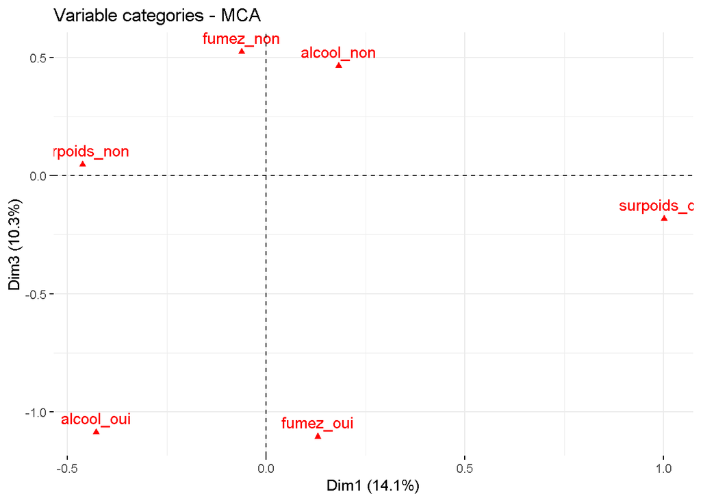

```r
fviz_mca_var(res.mca, axes=c(1,3),select.var = list(cos2 = 0.4))
```

```r
#légende:
#Tg=souffrez vous d'un taux de glycémie assez élevé?
#OE=Avez-vous déjà eu une opération sur l'estomac?
#OV=Avez vous déjà été opéré sur l'un de vos organes vitaux?
#Tc=Souffrez vous d'un taux de cholestérol assez élevé ?
#Allergie=Avez vous des allergies?
#Mchron =Souffrez-vous d’une maladie chronique?
#SSPORT =Est-ce que vous avez une condition de santé qui vous empêche de pratiquer du sport?
#FSpoids=avez vous quelqu'un de vos proches qui souffre d'un problème de surpoids?
#fumer=est ce que vous fumez?
#alcool=est-ce que vous buvez de l'alcool?
#surpoids=avez vous eu des problèmes de surpoids?
```

On remarque qu’il ya un lien assez fort entre le fait de ne pas fumer et de ne pas boire de l’alcool qui sont opposées sur le troisième axe à fumer_oui et a alcool_oui qui eux aussi possède un lien .

## 4)6)Interprétation de la deuxième carte des individus(axe 1 et 3)

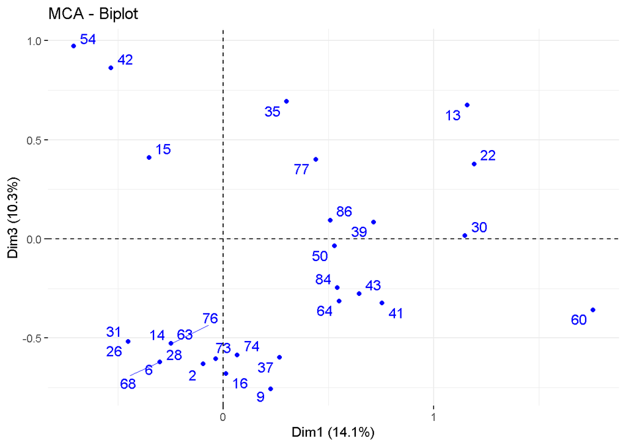

```r
fviz_mca_biplot(res.mca,axes = c(1,3),
               select.ind = list(contrib = 30),
               invisible ="var",repel = TRUE,
              ggtheme = theme_minimal ())
```

## 4)7)Interprétation de la troisième carte des modalités(axe 1 et 4)

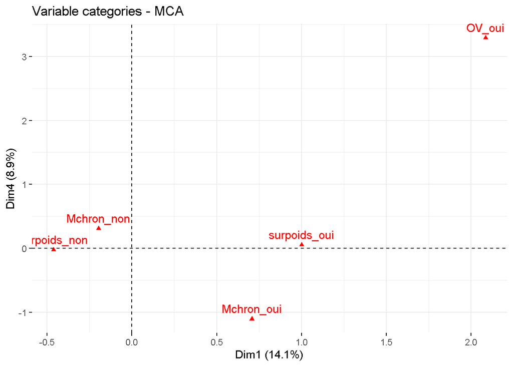

```r
fviz_mca_var(res.mca, axes=c(1,4),select.var = list(cos2 = 0.4))
```

```r
#légende:
#Tg=souffrez vous d'un taux de glycémie assez élevé?
#OE=Avez-vous déjà eu une opération sur l'estomac?
#OV=Avez vous déjà été opéré sur l'un de vos organes vitaux?
#Tc=Souffrez vous d'un taux de cholestérol assez élevé ?
#Allergie=Avez vous des allergies?
#Mchron =Souffrez-vous d’une maladie chronique?
#SSPORT =Est-ce que vous avez une condition de santé qui vous empêche de pratiquer du sport?
#FSpoids=avez vous quelqu'un de vos proches qui souffre d'un problème de surpoids?
#fumer=est ce que vous fumez?
#alcool=est-ce que vous buvez de l'alcool?
#surpoids=avez vous eu des problèmes de surpoids?
```

Cette carte donne deux nouvelles associations : surpoids_oui et Mchron_oui(lien entre le fait d’avoir un probleme de surpoid et le fait de souffrir d’une maladie chronique) surpoids_non et Mchron_non(lien entre le fait de ne pas avoir un probleme de surpoid et le fait de ne pas souffrir d’une maladie chronique))

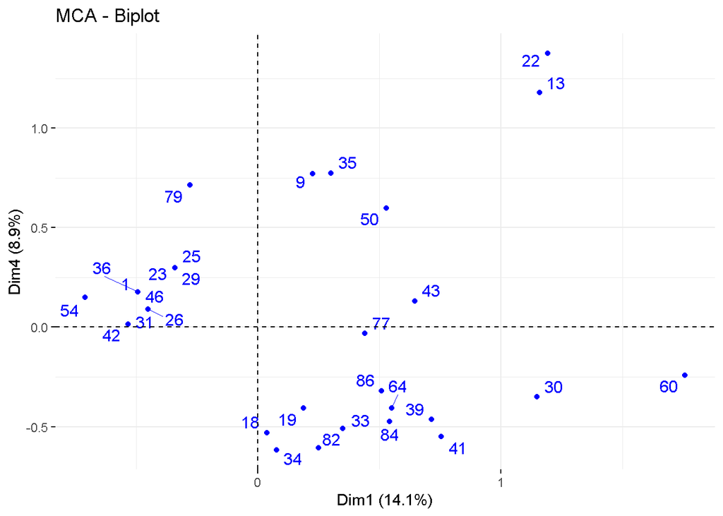

```r
fviz_mca_biplot(res.mca,axes = c(1,4),
               select.ind = list(contrib = 30),
               invisible ="var",repel = TRUE,
              ggtheme = theme_minimal ())
```

## 4)9)Interprétation de la quatrième carte des modalités(axe 2 et 3)

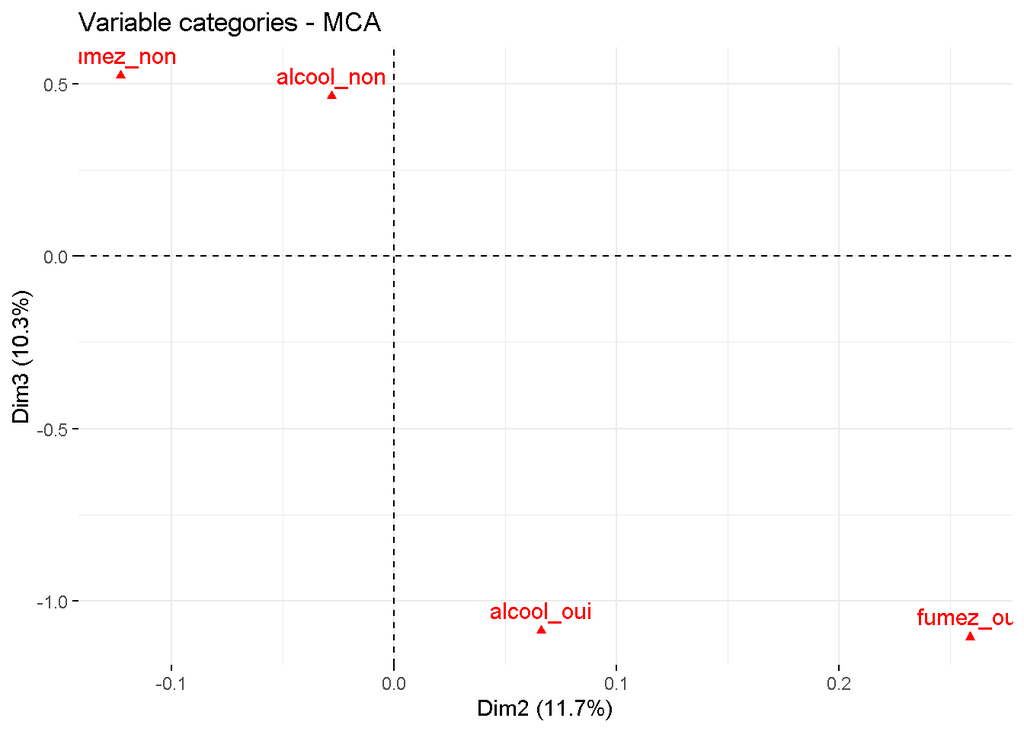

```r
fviz_mca_var(res.mca, axes=c(2,3),select.var = list(cos2 = 0.4))
```

```r
#légende:
#Tg=souffrez vous d'un taux de glycémie assez élevé?
#OE=Avez-vous déjà eu une opération sur l'estomac?
#OV=Avez vous déjà été opéré sur l'un de vos organes vitaux?
#Tc=Souffrez vous d'un taux de cholestérol assez élevé ?
#Allergie=Avez vous des allergies?
#Mchron =Souffrez-vous d’une maladie chronique?
#SSPORT =Est-ce que vous avez une condition de santé qui vous empêche de pratiquer du sport?
#FSpoids=avez vous quelqu'un de vos proches qui souffre d'un problème de surpoids?
#fumer=est ce que vous fumez?
#alcool=est-ce que vous buvez de l'alcool?
#surpoids=avez vous eu des problèmes de surpoids?
```

Aucune autre nouvelle association est constaté

## 4)10)Interprétation de la cinquième carte des modalités(axe 2 et 4)

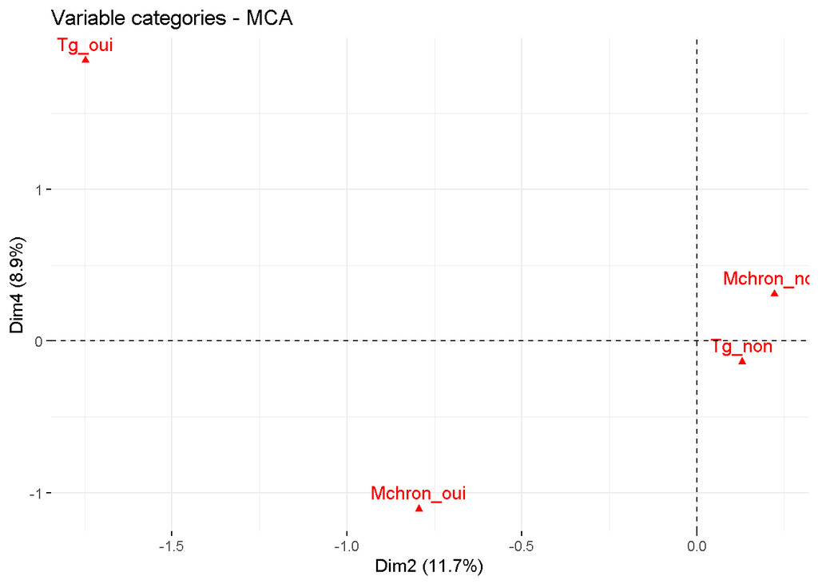

```r
fviz_mca_var(res.mca, axes=c(2,4),select.var = list(cos2 = 0.4))
```

```r
#légende:
#Tg=souffrez vous d'un taux de glycémie assez élevé?
#OE=Avez-vous déjà eu une opération sur l'estomac?
#OV=Avez vous déjà été opéré sur l'un de vos organes vitaux?
#Tc=Souffrez vous d'un taux de cholestérol assez élevé ?
#Allergie=Avez vous des allergies?
#Mchron =Souffrez-vous d’une maladie chronique?
#SSPORT =Est-ce que vous avez une condition de santé qui vous empêche de pratiquer du sport?
#FSpoids=avez vous quelqu'un de vos proches qui souffre d'un problème de surpoids?
#fumer=est ce que vous fumez?
#alcool=est-ce que vous buvez de l'alcool?
#surpoids=avez vous eu des problèmes de surpoids?
```

On remarque une association entre Tg_non et Mchron_non(lien entre le fait de ne pas avoir un taux de glycémie assez élevé et le faite de ne pas souffrir d’une maladie chronique) qui sont opposé sur le prmiere axe à Tg_oui et Mchron_oui

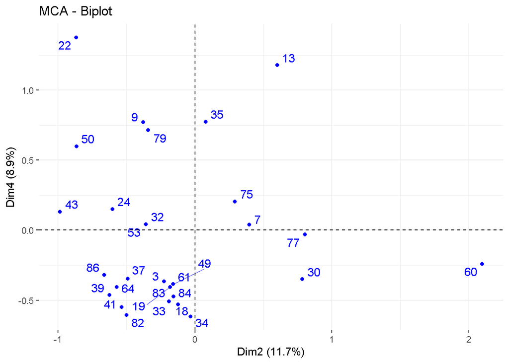

```r
fviz_mca_biplot(res.mca,axes = c(2,4),
               select.ind = list(contrib = 30),
               invisible ="var",repel = TRUE,
              ggtheme = theme_minimal ())
```

## 4)12)Interprétation de la sixième carte des modalités(axe 3 et 4)

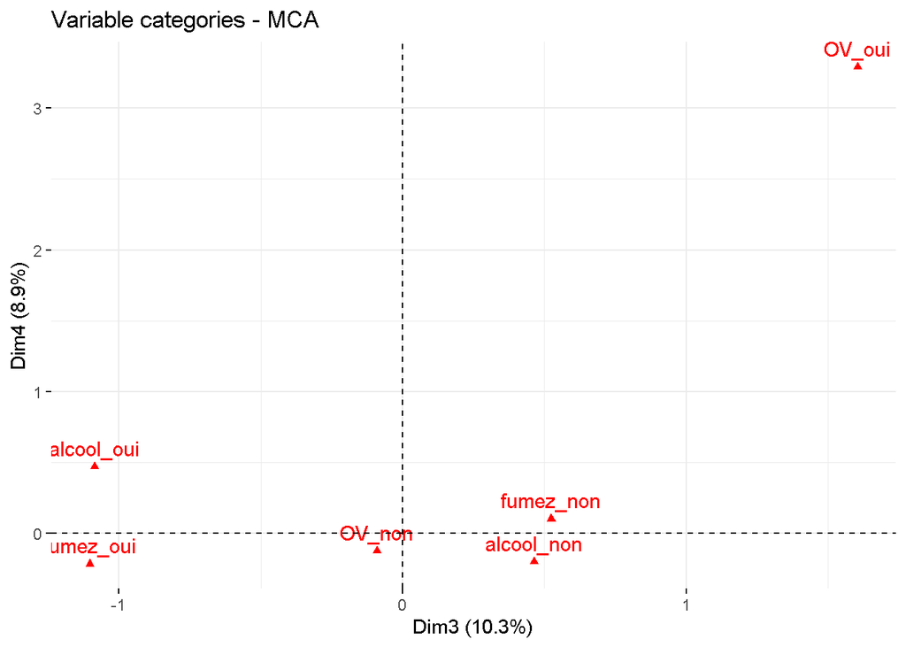

```r
fviz_mca_var(res.mca, axes=c(3,4),select.var = list(cos2 = 0.4))
```

```r
#légende:
#Tg=souffrez vous d'un taux de glycémie assez élevé?
#OE=Avez-vous déjà eu une opération sur l'estomac?
#OV=Avez vous déjà été opéré sur l'un de vos organes vitaux?
#Tc=Souffrez vous d'un taux de cholestérol assez élevé ?
#Allergie=Avez vous des allergies?
#Mchron =Souffrez-vous d’une maladie chronique?
#SSPORT =Est-ce que vous avez une condition de santé qui vous empêche de pratiquer du sport?
#FSpoids=avez vous quelqu'un de vos proches qui souffre d'un problème de surpoids?
#fumer=est ce que vous fumez?
#alcool=est-ce que vous buvez de l'alcool?
#surpoids=avez vous eu des problèmes de surpoids?
```

Aucune nouvelle association